# Chapter 2: Regression and model validation

#### 2.3.2. Multiple regression model of **point ~ attitude + stra**

Here I’m checking the linear regression of points ~ attitude and strategic learning approach outcome - I want to know if the strategic learning approach has a relationship to the exampoints of the students.

```r
# points ~ attitude + stra ----

att_st_lm <- lm(points ~ attitude + stra, data = lrn14_analysis)
att_st_lm_res <- summary(att_st_lm)
att_st_lm_res
```

```
##
## Call:
## lm(formula = points ~ attitude + stra, data = lrn14_analysis)
##
## Residuals:
##      Min       1Q   Median       3Q      Max
## -17.6482  -3.3135   0.5571   3.7966  10.9300
##
## Coefficients:
##             Estimate Std. Error t value Pr(>|t|)
## (Intercept)   8.9725     2.3966   3.744 0.000251 ***
## attitude      3.4664     0.5652   6.134 6.27e-09 ***
## stra          0.9132     0.5345   1.709 0.089438 .
## ---
## Signif. codes:  0 '***' 0.001 '**' 0.01 '*' 0.05 '.' 0.1 ' ' 1
##
## Residual standard error: 5.289 on 163 degrees of freedom
## Multiple R-squared:  0.2048, Adjusted R-squared:  0.195
## F-statistic: 20.99 on 2 and 163 DF,  p-value: 7.746e-09
```

```r
knitr::kable(att_st_lm_res$coefficients, digits=3, caption="Regression coefficients point ~ attitude + stra")
```

Regression coefficients point ~ attitude + stra

|  | Estimate | Std. Error | t value | Pr(>\|t\|) |
| --- | --- | --- | --- | --- |
| (Intercept) | 8.972 | 2.397 | 3.744 | 0.000 |
| attitude | 3.466 | 0.565 | 6.134 | 0.000 |
| stra | 0.913 | 0.534 | 1.709 | 0.089 |

Here the diagnostic plots of the regression model **points ~ attitude + stra**:

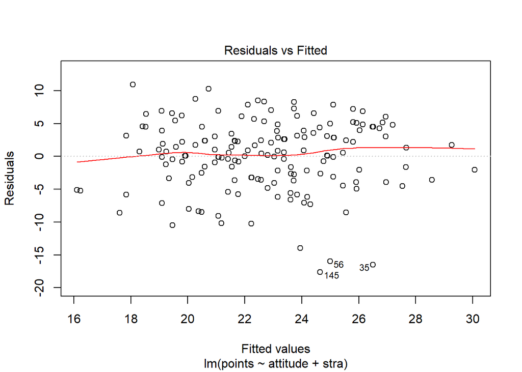

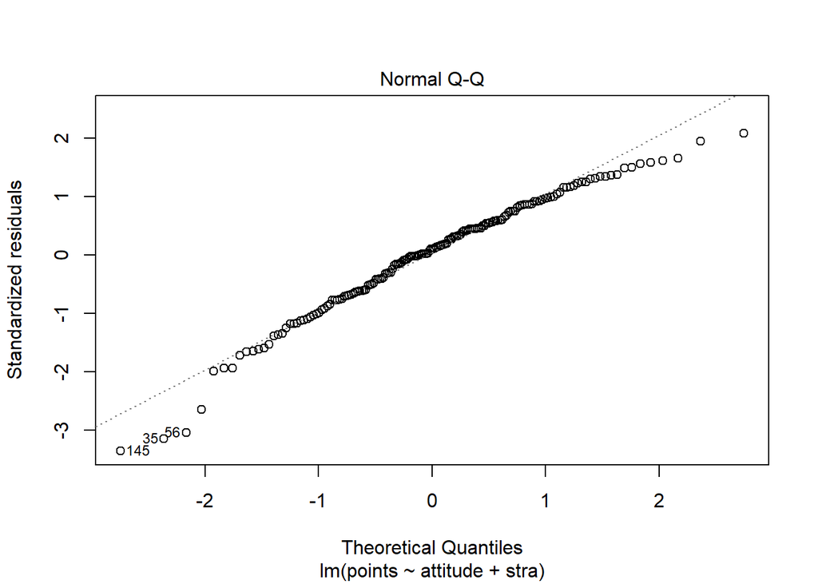

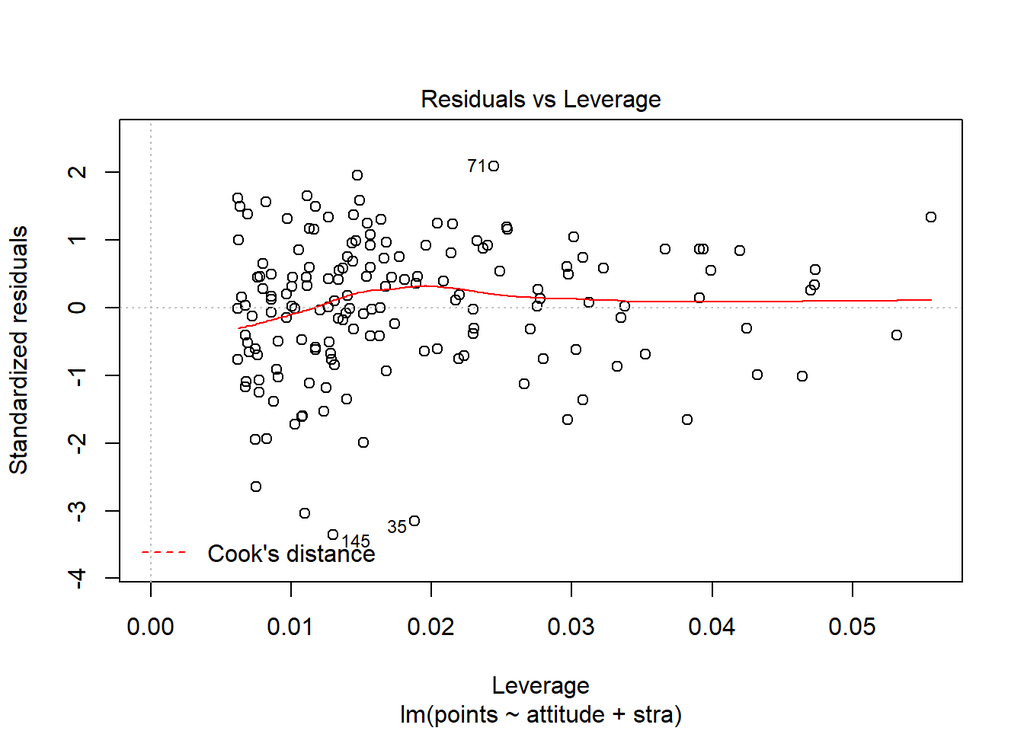

```r
plot(att_st_lm, which = c(1,2,5))
```

##### Regression model **point ~ attitude + stra** interpretation:

In this multiple regression I wanted to see if the strategic learning approach shows an influence on the amount of exampoints a student can reach. The outcome shows that the strategic learning approach has some influence but not a very strong one. Also the p-value of 0.08 shows that the significance of the influence is not very strong. The multiple R-squared is a bit higher compared to points ~ attitude regression model so we have a little higher correlations if we put the strategic learning approach into account.  
The diagnostic plots show more or less the same results as in the regression model point ~ attitude. Data is normal distributed and no outliers are significantly disturbing the analysis.

#### 2.3.3. Multiple regression model of **point ~ deep + surf + stra**

In the third regression model I put points vs. deep, surface and strategic learning approach into account. Does the combination of deep, surface and strategic learning approach have an influence in the exampoints of students.

```r
# points ~ + deep + surf + stra ----

de_su_st_lm <- lm(points ~ deep + surf + stra, data = lrn14_analysis)
de_su_st_lm_res <- summary(de_su_st_lm)

de_su_st_lm_res
```

```
##
## Call:
## lm(formula = points ~ deep + surf + stra, data = lrn14_analysis)
##
## Residuals:
##      Min       1Q   Median       3Q      Max
## -15.1208  -3.0725   0.5196   4.2798  10.3346
##
## Coefficients:
##             Estimate Std. Error t value Pr(>|t|)
## (Intercept)  26.9426     5.1147   5.268 4.34e-07 ***
## deep         -0.7472     0.8659  -0.863   0.3895
## surf         -1.6328     0.9149  -1.785   0.0762 .
## stra          0.9850     0.5962   1.652   0.1005
## ---
## Signif. codes:  0 '***' 0.001 '**' 0.01 '*' 0.05 '.' 0.1 ' ' 1
##
## Residual standard error: 5.827 on 162 degrees of freedom
## Multiple R-squared:  0.04072,    Adjusted R-squared:  0.02296
## F-statistic: 2.292 on 3 and 162 DF,  p-value: 0.0801
```

```r
knitr::kable(de_su_st_lm_res$coefficients, digits=3, caption="Regression coefficients point ~ deep + surf + stra")
```

Regression coefficients point ~ deep + surf + stra

|  | Estimate | Std. Error | t value | Pr(>\|t\|) |
| --- | --- | --- | --- | --- |
| (Intercept) | 26.943 | 5.115 | 5.268 | 0.000 |
| deep | -0.747 | 0.866 | -0.863 | 0.389 |
| surf | -1.633 | 0.915 | -1.785 | 0.076 |
| stra | 0.985 | 0.596 | 1.652 | 0.100 |

Here the diagnostic plots of the regression model **points ~ + deep + surf + stra**:

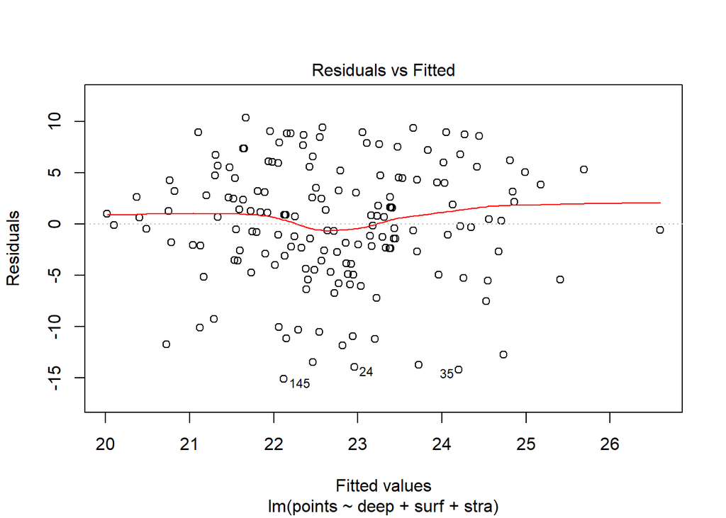

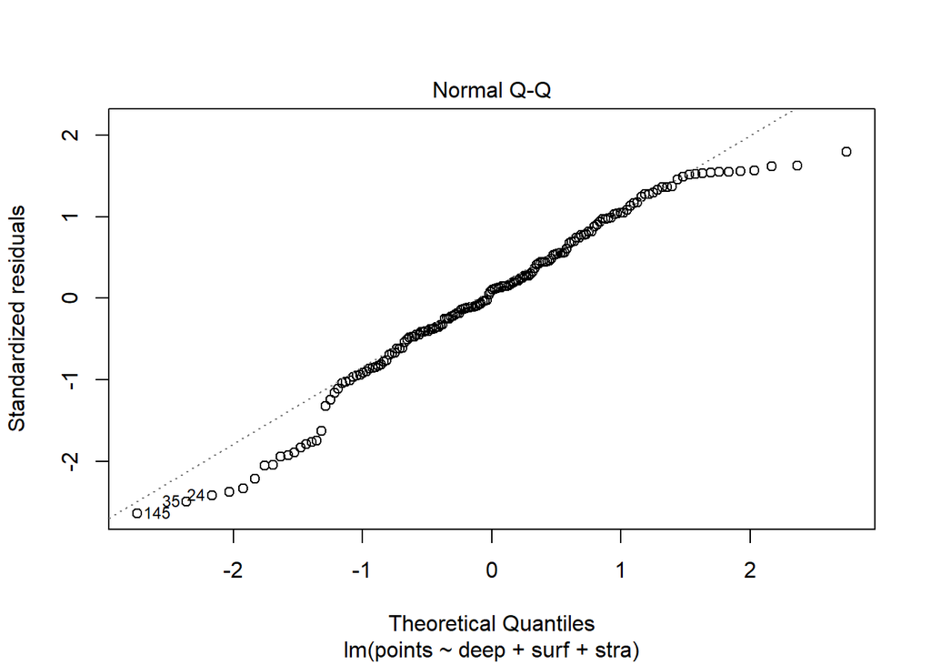

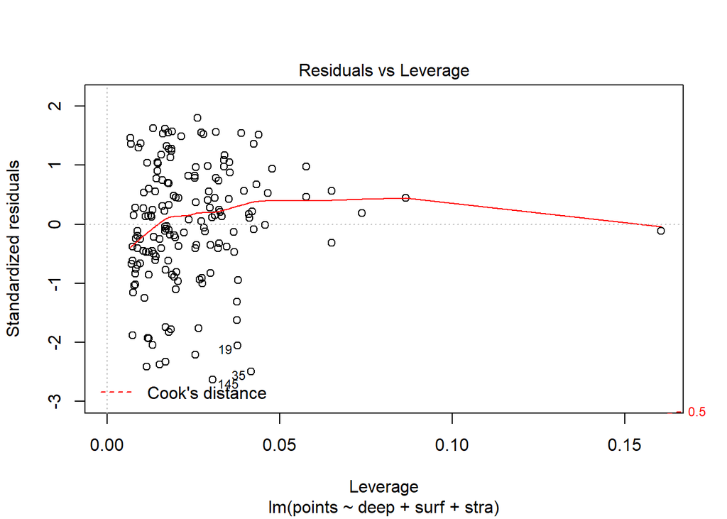

```r
plot(de_su_st_lm, which = c(1,2,5))
```

##### Regression model **point ~ deep + surf + stra** interpretation:

The outcome of this regression model shows that with a minor significance (0.0762) the surface learning approach has some indluence to the exam outcomes of students. Checking the estimate for surf show a negative value of -1.63 which means that students with a surface learning approach tent to have 1.6 points less as a test result with a increased surface learning approach value of 1. The deep learning approach seem to have no influence at all in the amount of points students reach at the exams and the stratetic approach has a non-significant positive influence.  
The multiple R-squared of 0.04 is very low and explains that there is more or less no correlation between these variables and the exampoints from the students.

Here I put the three variables into a `qplot()` to show the relationsships of the learning approaches and the exampoints.

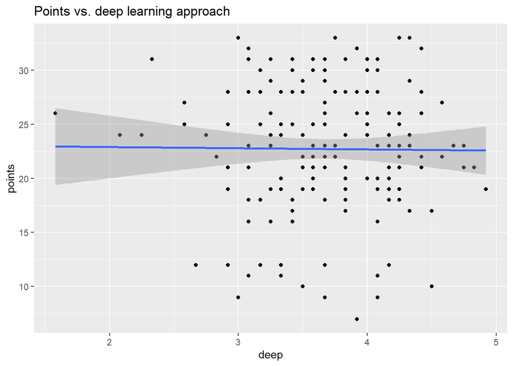

```r
library(ggplot2)
par(mfrow = c(2,2))
qplot(deep, points, data = lrn14_analysis) + geom_smooth(method = "lm") + ggtitle("Points vs. deep learning approach")
```

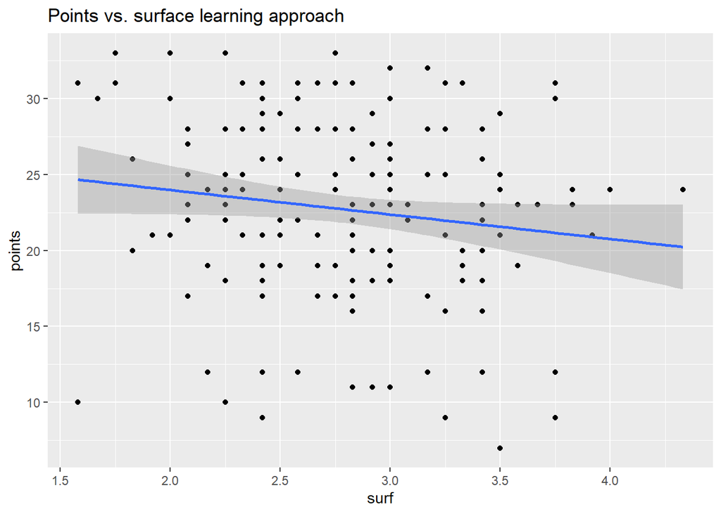

```r
qplot(surf, points, data = lrn14_analysis) + geom_smooth(method = "lm")+ ggtitle("Points vs. surface learning approach")
```

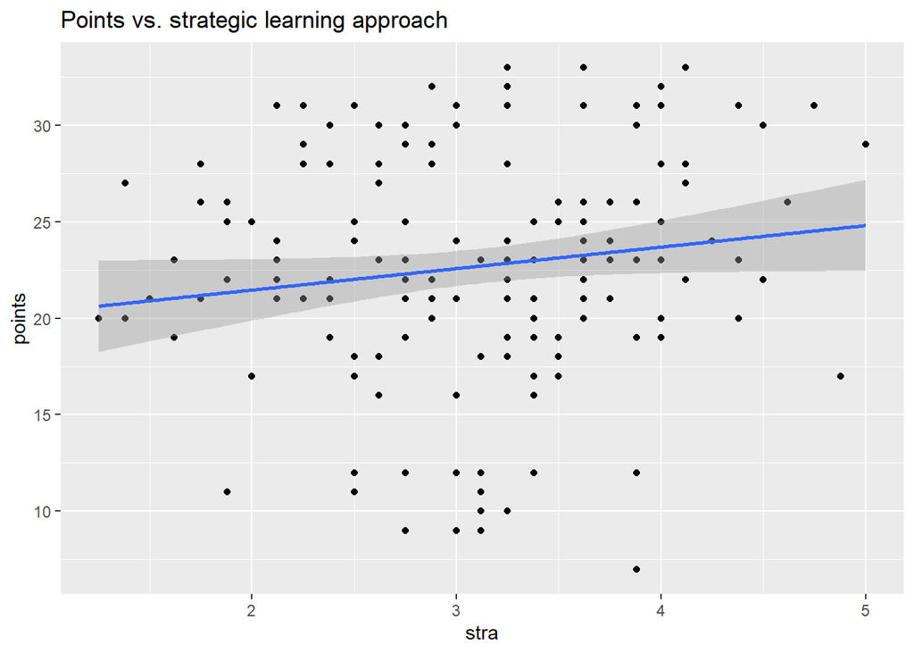

```r
qplot(stra, points, data = lrn14_analysis) + geom_smooth(method = "lm")+ ggtitle("Points vs. strategic learning approach")
```

So, this was a trial to analyse the dataset with simple and multiple regression models. I hope the interpretations are easily understood and the diary structure is not confusing you.  
I had fun preparing this first statistics and graph chapter and I’m looking forward to learn more…